# CRISPR_Cut and CRISPR_inhibition comparison

```r
setwd("E:/Paper writing/CRIPSRi paper/Analyses/CRISPR-CRISPRi_Comparison/pub_final")
library(tidyverse)
```

```r
library(ggpubr)
library(ggrepel)
library(ggsci)
library(ggExtra)
library(cowplot)
library(svglite)
library(reshape2)
```

##Here I compared CRISPRi screens with CRISPR screens in hIPSCI-Fiaj1 cell line # I used gene mean LFC for CRIPRi results, for CRISPR I used gene mean adjusted calculated LFC as reported in PEets et al, 2019 I retrieved TSS annotation from Fantom database (calculated before for this paper) and picked top TSS for IPSC I retrieved gRNA locations for Dolcetto A library from: https://portals.broadinstitute.org/gpp/public/pool/details?pool=CP0055

CP0055_9606_GRCh38_20181031_ontarget.bed file, it has 187507 entries since some guides target more than one region in genome. I assigned this guides as non unique in remaining analysis and did not include them in any analysis requiring TSS annotation or guide RNA locus info. for gene mean LFC file if either of 3 guides for a gene is non-unique, I labeled that gene as non-unique. distance to TSS is calculated as distange of PAM site to TSS and exact location of guide RNA spans either - and + 20bp of this location depending on which strand the guide is. merged annotated file is the result of these analysis.

```r
theme_su<-  function(){
  font <- "Arial"   #assign font family up front

  theme_bw() %+replace%    #replace elements we want to change

    theme(


      #text elements
      plot.title = element_text(             #title
        family = "Arial",            #set font family
        size = 8,                #set font size
        face = 'bold',            #bold typeface
        hjust = 0,                #left align
        vjust = 3),               #raise slightly

      plot.subtitle = element_text(          #subtitle
        family = "Arial",            #font family
        size = 6),               #font size

      plot.caption = element_text(           #caption
        family = "Arial",            #font family
        size = 6,                 #font size
        hjust = 1),               #right align

      axis.title = element_text(             #axis titles
        family = "Arial",

        size = 6),               #font size

      axis.text = element_text(              #axis text
        family = "Arial",            #axis famuly
        size = 6),                #font size

      axis.text.x = element_text(            #margin for axis text
        margin=margin(5, b = 10)),

     legend.title=element_text(
       family="Arial",
       size=8,
       hjust = 0),
     legend.text=element_text(
       family = "Arial",
       size=6),

     panel.grid.major = element_blank(),
     panel.grid.minor = element_blank()
     )



}
```

```r
merged_annotated <- read.csv("input/merged_annotated.txt")
```

```r
names(merged_annotated)
```

```
##  [1] "Gene"                      "Annot"
##  [3] "IPSC_1_inh"                "IPSC_2_inh"
##  [5] "K562_1_inh"                "K562_2_inh"
##  [7] "IPSC_AV_inh"               "K562_Av_inh"
##  [9] "IPSC_Av_Cut"               "K562_Av_cut"
## [11] "iPSC_1_cut"                "iPSC_2_cut"
## [13] "chr"                       "strand.y"
## [15] "Count"                     "tss_id"
## [17] "tss_start"                 "start"
## [19] "TSS_distance"              "Unique"
## [21] "chr_type"                  "distance"
## [23] "bidirectional"             "distance_to_neighbour_TSS"
## [25] "max_off_target"            "crispr_off_target"
```

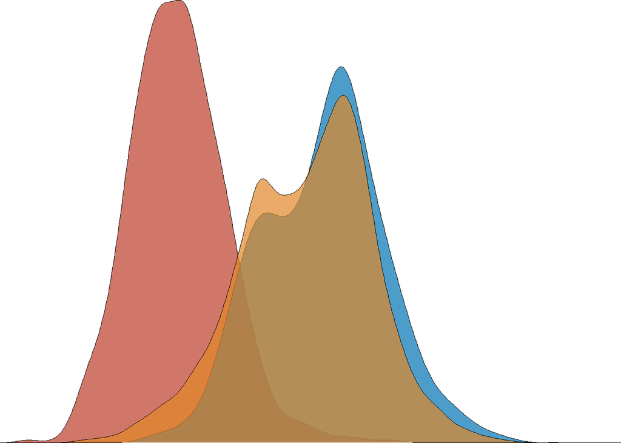

```r
scatter1<- ggplot()+
  geom_point(data=(merged_annotated %>% filter(Annot=="Other") %>% droplevels()), aes(x=IPSC_Av_Cut, y= IPSC_AV_inh, color="Other"),size=0.05, alpha=0.5)+
  geom_point(data=(merged_annotated %>% filter(Annot=="CEG") %>% droplevels()), aes(x=IPSC_Av_Cut, y= IPSC_AV_inh, color="CEG"),size=0.05, alpha=0.5)+
  geom_point(data=(merged_annotated %>% filter(Annot=="NEG") %>% droplevels()), aes(x=IPSC_Av_Cut, y= IPSC_AV_inh, color="NEG"),size=0.05, alpha=0.5)+
ggtitle("Comparison of CRISPR and CRISPR-inhibition screens in hIPSC Cells")+ xlab("CRISPR Gene Average Log2 Fold Change")+ylab("CRISPR-inhibition Gene Average Log2 Fold Change")+theme_su()+ scale_color_nejm(name="Gene Function",                                                               labels=c("CEG"="Core Essential Genes" , "NEG"="Non-Essential Genes",  "Non-targeting_control"="Control", "Other"="Other Genes"))+theme(legend.position = "bottom")


scatter1<- scatter1+ stat_cor(data=merged_annotated, aes(x=IPSC_Av_Cut, y= IPSC_AV_inh, label = ..r.label..), inherit.aes = F, size=2)

xdens <- axis_canvas(scatter1, axis = "x")+
  geom_density(data = merged_annotated, aes(x = IPSC_Av_Cut, fill = Annot),
              alpha = 0.7, size = 0.2)+
 scale_fill_nejm()
xdens
```

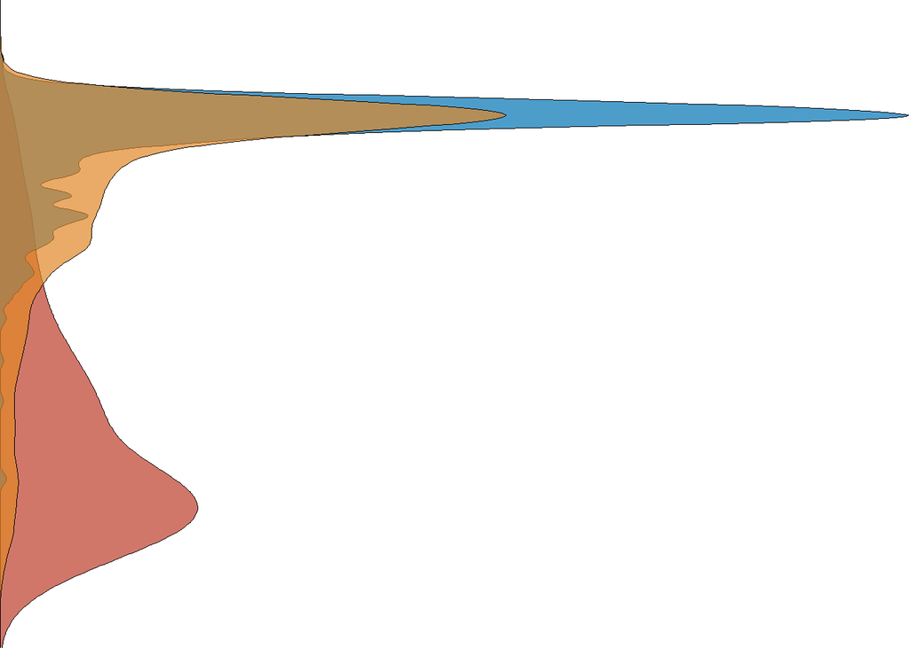

```r
ydens <- axis_canvas(scatter1, axis = "y", coord_flip = T)+
  geom_density(data = merged_annotated, aes(x = IPSC_AV_inh, fill = Annot),
              alpha = 0.7, size = 0.2)+
 scale_fill_nejm()+coord_flip()
ydens
```

```r
p1 <- insert_xaxis_grob(scatter1, xdens, grid::unit(.2, "null"), position = "top")
```

[output not shown]

[output cut: 28 more lines]

[output not shown]

[output not shown]

[output cut: 67 more lines]

[output not shown]

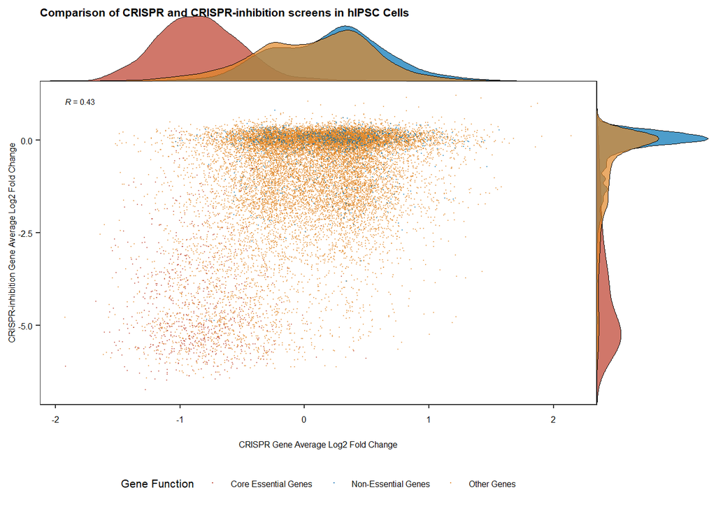

```r
p2<- insert_yaxis_grob(p1, ydens, grid::unit(.2, "null"), position = "right")
fig_4_a<- ggdraw(p2)
fig_4_a
```

```r
ggsave(fig_4_a, filename = "E:/Paper writing/CRIPSRi paper/Analyses/plots/panel_4/fig_4_a.svg", width = 4, height = 3.5, units = "in", dpi=1000)
```

### Chromosome Type Effect:

```r
names(merged_annotated)
```

```
##  [1] "Gene"                      "Annot"
##  [3] "IPSC_1_inh"                "IPSC_2_inh"
##  [5] "K562_1_inh"                "K562_2_inh"
##  [7] "IPSC_AV_inh"               "K562_Av_inh"
##  [9] "IPSC_Av_Cut"               "K562_Av_cut"
## [11] "iPSC_1_cut"                "iPSC_2_cut"
## [13] "chr"                       "strand.y"
## [15] "Count"                     "tss_id"
## [17] "tss_start"                 "start"
## [19] "TSS_distance"              "Unique"
## [21] "chr_type"                  "distance"
## [23] "bidirectional"             "distance_to_neighbour_TSS"
## [25] "max_off_target"            "crispr_off_target"
```

```r
a<- merged_annotated %>% filter(chr_type!="Non-unique") %>% droplevels() %>% select(IPSC_Av_Cut, IPSC_AV_inh,chr_type) %>% melt()
```

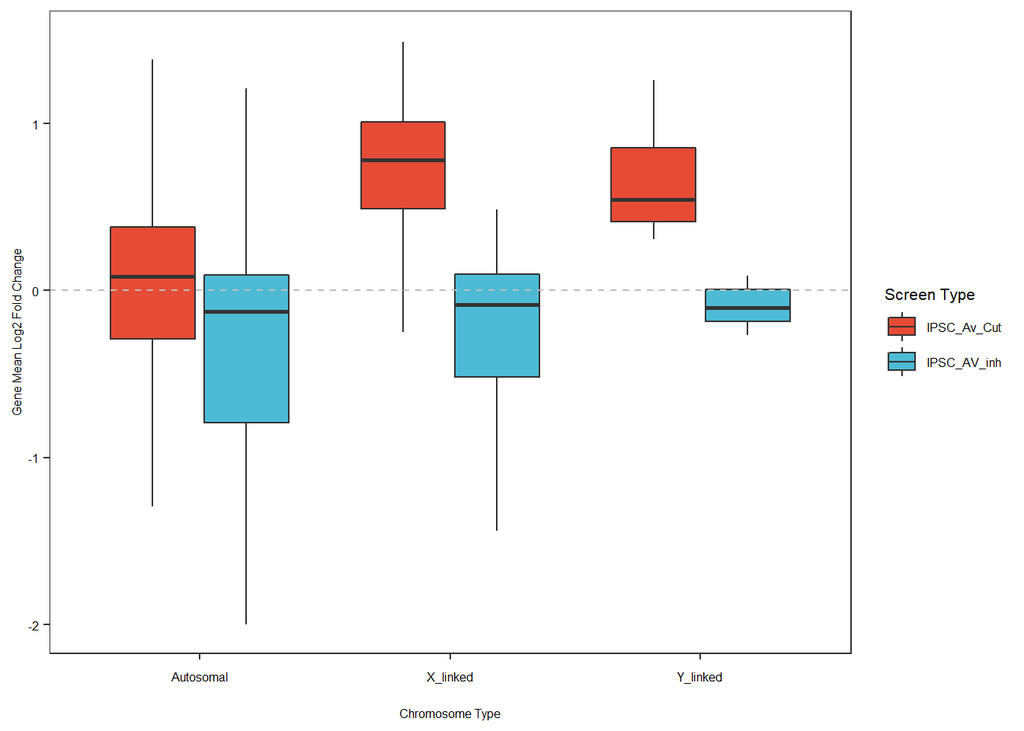

```r
fig_4_b<-a %>% ggplot(aes(x=chr_type, y=value, fill=variable))+geom_boxplot(outlier.shape = NA)+theme_su()+xlab("Chromosome Type")+ylab("Gene Mean Log2 Fold Change")+scale_fill_npg(name="Screen Type")+geom_hline(yintercept = 0, linetype="dashed", color="gray")+ylim(-2,1.5)
fig_4_b
```

```r
ggsave(fig_4_b, filename = "E:/Paper writing/CRIPSRi paper/Analyses/plots/panel_4/fig_4_b.svg", width = 4, height = 2, units = "in", dpi=1000)
```

### Effect of bidirectional promoters

```r
bidirectional_genes<- merged_annotated %>% filter(bidirectional=="<1000") %>% arrange(chr,tss_start)
print(paste("There are",nrow(bidirectional_genes), "gene pairs with less than 1000bp distance between promoters"))
```

```
## [1] "There are 1942 gene pairs with less than 1000bp distance between promoters"
```

[output not shown]

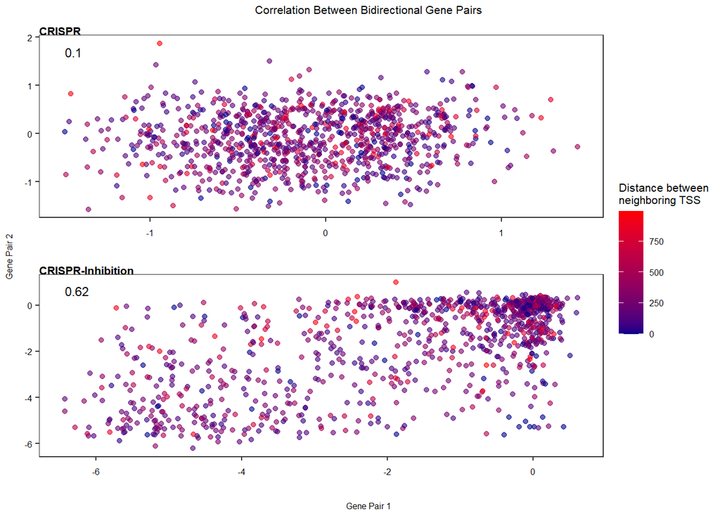

```r
## identify gene pairs



bidirectional_genes <- bidirectional_genes %>% mutate(neighbourgene=
  if_else(distance_to_neighbour_TSS == lead(distance_to_neighbour_TSS), lead(Gene), lag(Gene)))

bidirectional_genes<- bidirectional_genes %>% select(Gene, neighbourgene, chr, tss_start, distance_to_neighbour_TSS, IPSC_AV_inh,IPSC_Av_Cut, distance_to_neighbour_TSS, TSS_distance)
c<- bidirectional_genes %>% select(neighbourgene=Gene, neigh_IPSC_Av_Cut=IPSC_Av_Cut, neigh_IPSC_AV_inh=IPSC_AV_inh)
bidirectional_genes<- inner_join(bidirectional_genes,c, by="neighbourgene")

# select every second row to have only one copy of pairs
bidirectional_genes<- bidirectional_genes[seq(1, nrow(bidirectional_genes), 2), ]

## there are 971 gene pairs with bidirectional promoters

crispri_bidirectional_scatter<- bidirectional_genes %>% ggplot(aes(x=IPSC_AV_inh, y=neigh_IPSC_AV_inh, color=distance_to_neighbour_TSS))+geom_point(alpha=0.6)+stat_cor(aes(label=paste(..r..)), size=3)+ scale_color_gradient(name="Distance between \nneighboring TSS",low = "darkblue", high = "red")+theme_su()+xlab("Gene Pair 1")+ylab("Gene Pair 2")+ ggtitle("CRISPR-Inhibition")+theme(axis.title.x = element_blank(), axis.title.y = element_blank())



crispr_bidirectional_scatter<- bidirectional_genes %>% ggplot(aes(x=IPSC_Av_Cut, y=neigh_IPSC_Av_Cut, color=distance_to_neighbour_TSS))+geom_point(alpha=0.6)+stat_cor(aes(label=paste(..r..)), size=3)+ scale_color_gradient(name="Distance between \nneighboring TSS",low = "darkblue", high = "red")+theme_su()+xlab("Gene Pair 1")+ylab("Gene Pair 2")+ ggtitle("CRISPR")+theme(axis.title.x = element_blank(), axis.title.y = element_blank())


fig_4_d<-ggarrange(crispr_bidirectional_scatter, crispri_bidirectional_scatter, common.legend = T, legend = "right", ncol=1)
fig_4_d<-annotate_figure(fig_4_d,
                left = text_grob("Gene Pair 2", rot = 90, size=6), bottom=text_grob("Gene Pair 1", size=6), top = text_grob("Correlation Between Bidirectional Gene Pairs", size=8))
fig_4_d
```

```r
ggsave(fig_4_d, filename = "E:/Paper writing/CRIPSRi paper/Analyses/plots/panel_4/fig_4_d.svg", width = 3, height = 3, units = "in", dpi=1000)
```

### effect of unique gene annotation

some guides in Dolcetto library targets more than one loci on the genome. If a gene has at least one non-specific guide RNA, I labelled that gene as non-unique. I considered non-unique genes as the one with high level of homology within human genome. I compared depletion of non essential genes in unique and non-unique sets.

```r
print(paste(nrow(merged_annotated), "genes are involved in this stuy/ only",nrow(merged_annotated %>% filter(Unique=="Unique")), "are unique"))
```

```
## [1] "18558 genes are involved in this stuy/ only 17067 are unique"
```

I selected non-essential genes, filtered out genes with bidirectional promoters

[output not shown]

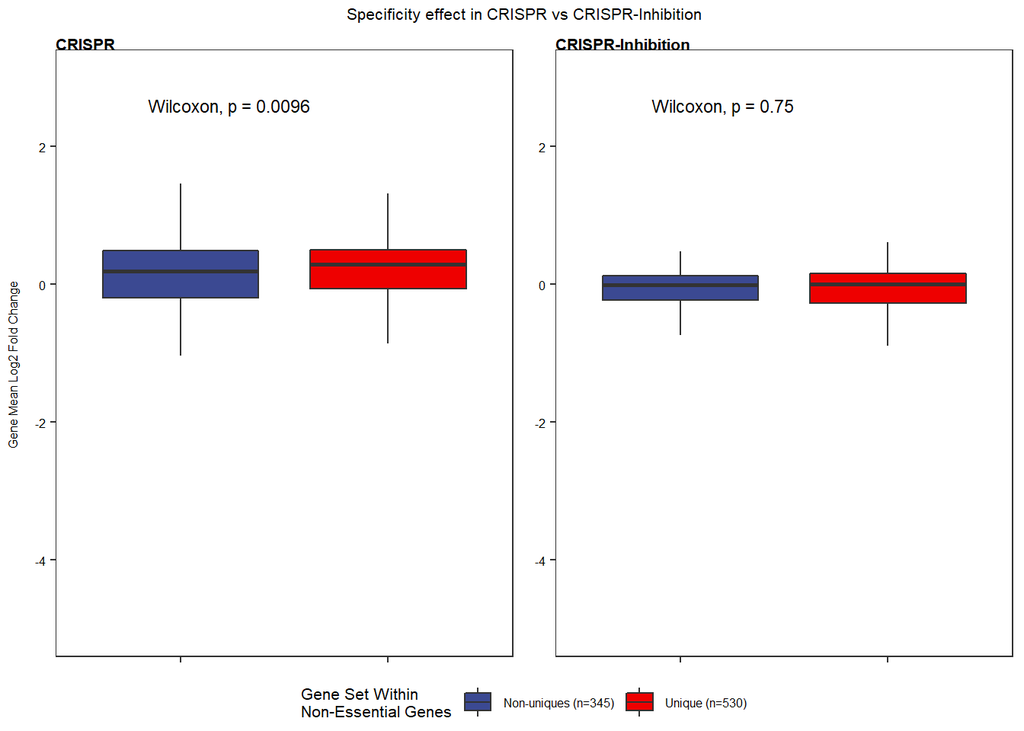

```r
non_essentials<- merged_annotated %>% filter(Annot=="NEG") %>% filter(is.na(bidirectional)) %>% select(Gene, IPSC_Av_Cut, IPSC_AV_inh, Unique, Annot)

nones_1<-non_essentials %>% ggplot(aes(y=IPSC_Av_Cut, x=Unique, fill=Unique))+geom_boxplot(outlier.shape = NA)+stat_compare_means(size=3, label.y=2.5)+theme_su()+scale_fill_aaas(name="Gene Set Within \nNon-Essential Genes", labels=c("Non-unique"="Non-uniques (n=345)", "Unique"="Unique (n=530)"))+ggtitle("CRISPR")+theme(axis.title = element_blank(), axis.text.x = element_blank())+ylim(-5,3)



nones_2<-non_essentials %>% ggplot(aes(y=IPSC_AV_inh,x=Unique, fill=Unique))+geom_boxplot(outlier.shape = NA)+stat_compare_means(size=3, label.y=2.5)+
  theme_su()+scale_fill_aaas(name="Gene Set Within \nNon-Essential Genes", labels=c("Non-unique"="Non-uniques (n=345)", "Unique"="Unique (n=530)"))+ggtitle("CRISPR-Inhibition")+theme(axis.title = element_blank(), axis.text.x = element_blank())+ylim(-5,3)
sup_fig_4_a<- ggarrange(nones_1, nones_2, nrow=1, common.legend = T, legend = "bottom")
sup_fig_4_a<-annotate_figure(sup_fig_4_a, top = text_grob("Specificity effect in CRISPR vs CRISPR-Inhibition", size=8), left = text_grob("Gene Mean Log2 Fold Change",rot=90, size=6))
sup_fig_4_a
```

```r
ggsave(sup_fig_4_a, filename = "E:/Paper writing/CRIPSRi paper/Analyses/plots/panel_4/sup_fig_4_a.svg", width = 4, height = 4, units = "in", dpi=1000)
```

### non-unique effect for crispr

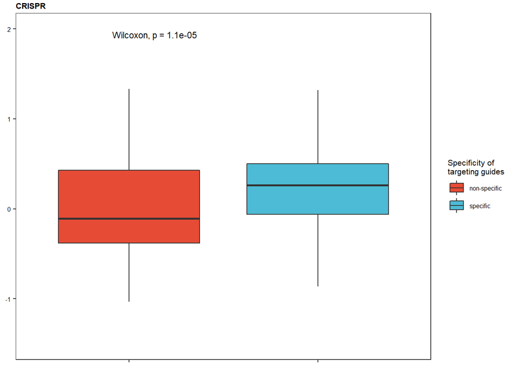

```r
crispr_specific<- merged_annotated %>%  filter(Annot=="NEG") %>% filter(crispr_off_target!="no_data") %>%  ggplot(aes(y=IPSC_Av_Cut, x=crispr_off_target, fill=crispr_off_target))+geom_boxplot(outlier.shape = NA)+stat_compare_means(size=3, label.y=1.9)+ theme_su()+ scale_fill_npg(name="Specificity of \ntargeting guides")+theme(axis.title = element_blank(), axis.text.x = element_blank())+ggtitle("CRISPR")+ylim(-1.5,2)
crispr_specific
```

[output not shown]

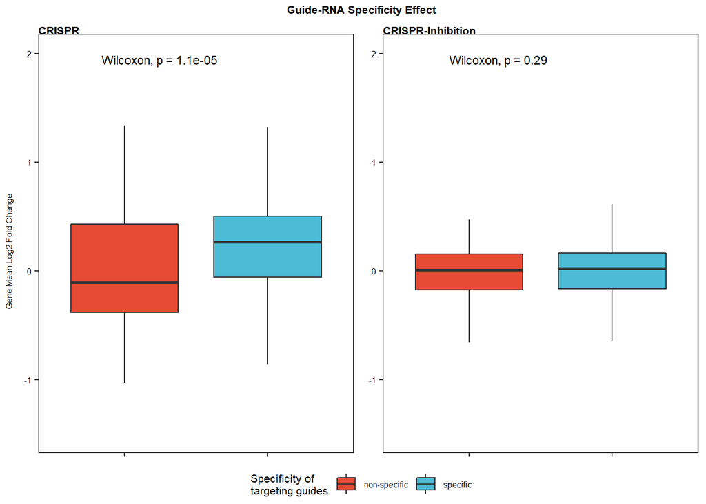

```r
crispri_unique<-
merged_annotated %>%  filter(Annot=="NEG")  %>% filter(is.na(bidirectional)) %>%  ggplot(aes(y=IPSC_AV_inh, x=Unique, fill=Unique))+geom_boxplot(outlier.shape = NA)+stat_compare_means(size=3, label.y = 1.9)+ theme_su()+ scale_fill_npg(name="Specificity of \ntargeting guides", labels=(c("Non-unique"="Non-Specific", "Unique"="Specific")))+theme(axis.title = element_blank(), axis.text.x = element_blank())+ggtitle("CRISPR-Inhibition")+ylim(-1.5,2)

sup_fig_4_b<- ggarrange(crispr_specific, crispri_unique, common.legend = T, legend = "bottom")
sup_fig_4_b<- annotate_figure(sup_fig_4_b, left=text_grob("Gene Mean Log2 Fold Change", size=6, rot=90), top = text_grob("Guide-RNA Specificity Effect", size=8, face="bold"))
sup_fig_4_b
```

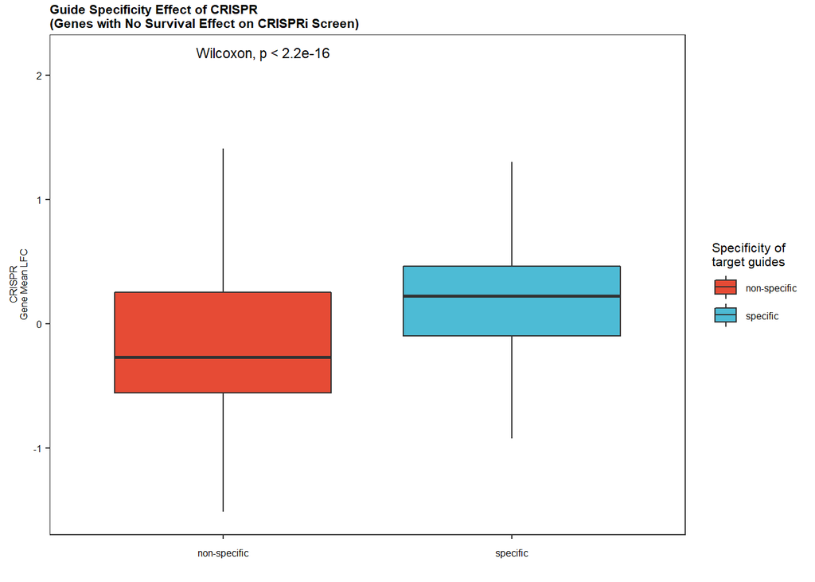

```r
ggsave(sup_fig_4_b, filename = "E:/Paper writing/CRIPSRi paper/Analyses/plots/panel_4/sup_fig_4_b.svg", width = 4, height = 4, units = "in", dpi=1000)




fig_4_c<- merged_annotated %>% filter(IPSC_AV_inh > -0.4 & IPSC_AV_inh< 0.4 ) %>% filter(crispr_off_target != "no_data") %>%  ggplot(aes(y=IPSC_Av_Cut, x=crispr_off_target, fill=crispr_off_target))+geom_boxplot(outlier.shape = NA)+stat_compare_means(size=3)+ scale_fill_npg(name="Specificity of \ntarget guides")+theme_su()+ ylab("CRISPR\nGene Mean LFC")+ theme(axis.title.x = element_blank())+ggtitle("Guide Specificity Effect of CRISPR\n(Genes with No Survival Effect on CRISPRi Screen)")
fig_4_c
```

```r
ggsave(fig_4_c, filename = "E:/Paper writing/CRIPSRi paper/Analyses/plots/panel_4/fig_4_c.svg", width = 3.5, height = 3, units = "in",dpi=1000)
```

###compare replicates

```r
names(merged_annotated)
```

```
##  [1] "Gene"                      "Annot"
##  [3] "IPSC_1_inh"                "IPSC_2_inh"
##  [5] "K562_1_inh"                "K562_2_inh"
##  [7] "IPSC_AV_inh"               "K562_Av_inh"
##  [9] "IPSC_Av_Cut"               "K562_Av_cut"
## [11] "iPSC_1_cut"                "iPSC_2_cut"
## [13] "chr"                       "strand.y"
## [15] "Count"                     "tss_id"
## [17] "tss_start"                 "start"
## [19] "TSS_distance"              "Unique"
## [21] "chr_type"                  "distance"
## [23] "bidirectional"             "distance_to_neighbour_TSS"
## [25] "max_off_target"            "crispr_off_target"
```

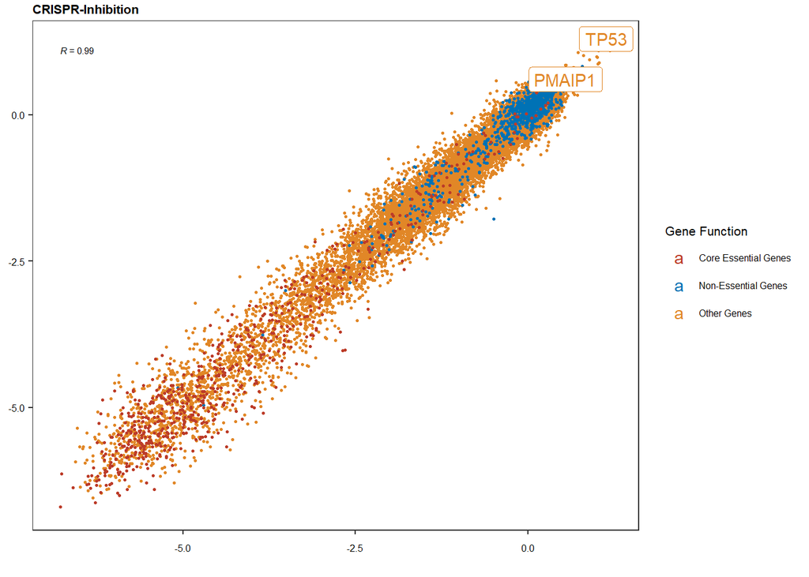

```r
inh_replicates<-
ggplot()+
  geom_point(data=(merged_annotated %>% filter(Annot=="Other")),aes(x=IPSC_1_inh, y=IPSC_2_inh, color=Annot), size=0.5)+
  geom_point(data=(merged_annotated %>% filter(Annot=="NEG")),aes(x=IPSC_1_inh, y=IPSC_2_inh,color=Annot), size=0.5)+
  geom_point(data=(merged_annotated%>% filter(Annot=="CEG")),aes(x=IPSC_1_inh, y=IPSC_2_inh,color=Annot), size=0.5)+
  stat_cor(data=merged_annotated, inherit.aes = F, aes(x=IPSC_1_inh, y=IPSC_2_inh,label = ..r.label..), method = "pearson", size=2)+
  ggtitle("CRISPR-Inhibition")+
  theme_su()+
  scale_color_nejm(name="Gene Function",                                                          labels=c("CEG"="Core Essential Genes" , "NEG"="Non-Essential Genes", "Other"="Other Genes"))+theme(axis.title = element_blank())+ geom_label_repel(data=(merged_annotated %>% filter(Gene %in% c("TP53", "PMAIP1"))), aes(x=IPSC_1_inh, y=IPSC_2_inh,color=Annot, label=Gene))
inh_replicates
```

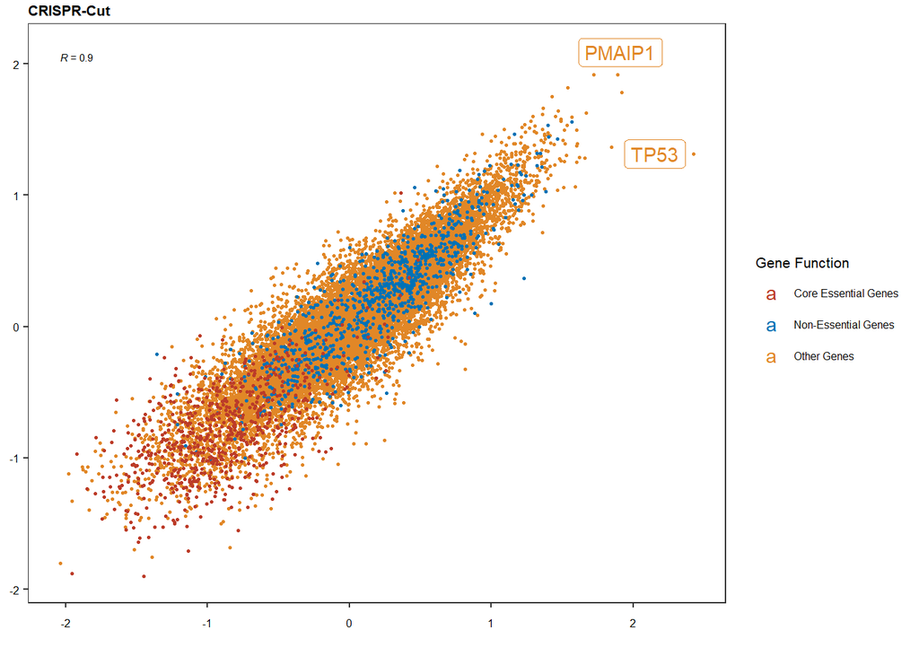

```r
cut_replicates<- ggplot()+
  geom_point(data=(merged_annotated %>% filter(Annot=="Other")),aes(x=iPSC_1_cut, y=iPSC_2_cut, color=Annot), size=0.5)+
  geom_point(data=(merged_annotated %>% filter(Annot=="NEG")),aes(x=iPSC_1_cut, y=iPSC_2_cut,color=Annot), size=0.5)+
  geom_point(data=(merged_annotated%>% filter(Annot=="CEG")),aes(x=iPSC_1_cut, y=iPSC_2_cut,color=Annot), size=0.5)+
  stat_cor(data=merged_annotated, inherit.aes = F, aes(x=iPSC_1_cut, y=iPSC_2_cut,label = ..r.label..), method = "pearson", size=2)+
  ggtitle("CRISPR-Cut")+
  theme_su()+
  scale_color_nejm(name="Gene Function",                                                          labels=c("CEG"="Core Essential Genes" , "NEG"="Non-Essential Genes", "Other"="Other Genes"))+theme(axis.title = element_blank())+ geom_label_repel(data=(merged_annotated %>% filter(Gene %in% c("TP53", "PMAIP1"))), aes(x=iPSC_1_cut, y=iPSC_2_cut,color=Annot, label=Gene))
cut_replicates
```

```r
sup_fig_4_c<- ggarrange(inh_replicates, cut_replicates, nrow=1, common.legend = T, legend = "bottom")
sup_fig_4_c<- annotate_figure(sup_fig_4_c, top=text_grob("Replicate Correlation\nCRISPR-Inhibition vs CRISPR Cut", size=8, face="bold"), bottom = text_grob("Gene Mean Log2 Fold Change", size=6,), left=text_grob("Gene Mean Log2 Fold Change", size=6, rot=90))
sup_fig_4_c
```

[output not shown]

[figure not shown]

```r
ggsave(sup_fig_4_c, filename = "E:/Paper writing/CRIPSRi paper/Analyses/plots/panel_4/sup_fig_4_c.svg", width = 4, height = 3, units = "in", dpi=1000)
```

###compare depletion pattern

```r
crispri_guide_LFC<- read_csv(file="input/crispri_guide_lfc.txt")
names(crispri_guide_LFC)
```

```
## [1] "Guide.Sequence" "Gene"           "func"           "IPSC_D18"
## [5] "K562_D21"
```

```r
crispr_guide<- read_csv(file="input/crispr_guide_lfc.txt")
crispr_guide<- do.call("data.frame",crispr_guide)
names(crispr_guide)
```

```
## [1] "gRNA"     "Type"     "Gene"     "K562_LFC" "iPSC_LFC"
```

```r
annotation<- unique(crispri_guide_LFC %>% select(Gene,func))

crispr_guide <- left_join(crispr_guide, annotation, by="Gene")
crispr_guide<- do.call(data.frame,crispr_guide)
summary(crispr_guide$func)
```

```
##    CEG    NEG  Other   NA's
##   3960   5302 104366   5524
```

```r
crispr_guide<- crispr_guide %>% mutate(func=case_when(
  Gene=="Non-targeting_control"~ "CONTROL",
TRUE ~ as.character(func)))
crispr_guide<- do.call(data.frame,crispr_guide)
summary(crispr_guide$func )
```

```
##     CEG CONTROL     NEG   Other    NA's
##    3960    1592    5302  104366    3932
```

```r
crispr_guide<-crispr_guide %>% filter(!is.na(func))
crispr_guide<- crispr_guide %>% separate(gRNA, into=c("gRNA", "library"), sep = "_")
```

```r
mean_inh<- crispri_guide_LFC %>% select(func, IPSC_D18) %>%  group_by(func) %>% summarise(across(
    .cols = where(is.numeric),
    .fns = list(Mean = mean), na.rm = TRUE,
    .names = "{col}_{fn}"
  )) %>% droplevels()
mean_cut<-crispr_guide %>% filter(library==3) %>% select(func, iPSC_LFC) %>%  group_by(func) %>% summarise(across(
    .cols = where(is.numeric),
    .fns = list(Mean = mean), na.rm = TRUE,
    .names = "{col}_{fn}"
  )) %>% droplevels()

level_order<- c("CEG", "NEG", "Other", "CONTROL")

mean_cut
```

| func | iPSC_LFC_Mean |
| --- | --- |
| CEG | -2.2992084 |
| CONTROL | 0.6794849 |
| NEG | -1.0212473 |
| Other | -1.1945056 |

[output not shown]

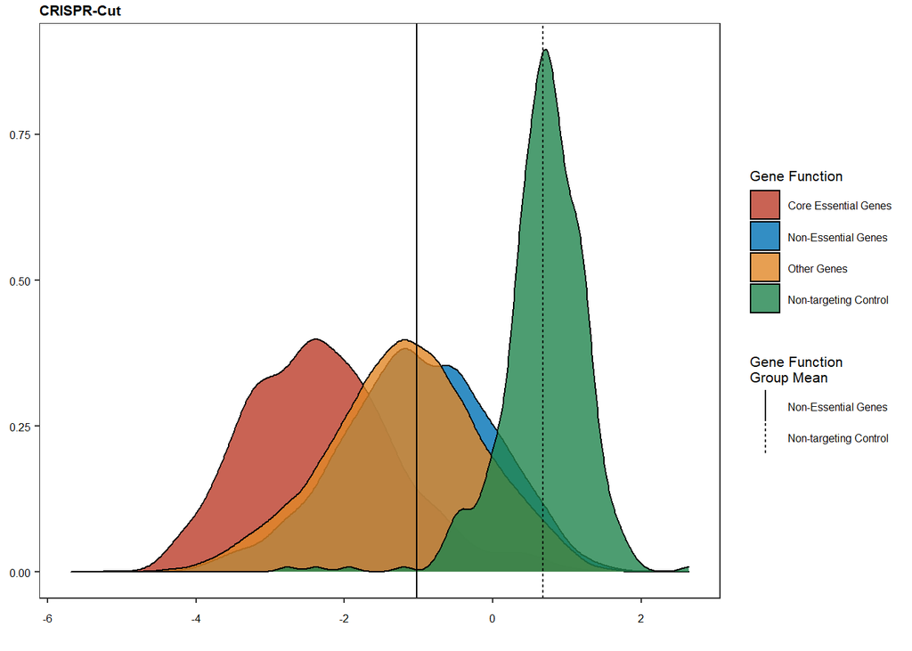

```r
density_cut<-crispr_guide %>% filter(library==3) %>%  ggplot(aes(x=iPSC_LFC,fill=factor(func, level=level_order)))+geom_density(color="black", alpha=0.8)+
  scale_fill_nejm(name="Gene Function",                                                          labels=c("CEG"="Core Essential Genes" , "NEG"="Non-Essential Genes", "Other"="Other Genes", "CONTROL"="Non-targeting Control"))+
  theme_su()+
  theme(axis.title = element_blank())+ggtitle("CRISPR-Cut ")+
 geom_vline(aes(xintercept=0.679, linetype="Non-targeting Control"))+
  geom_vline(aes(xintercept= -1.02, linetype="Non-Essential Genes"))+scale_linetype(name="Gene Function\nGroup Mean")

density_cut
```

```r
mean_inh
```

| func | IPSC_D18_Mean |
| --- | --- |
| CEG | -2.9947156 |
| CONTROL | 0.2431160 |
| NEG | 0.1292245 |
| Other | -0.3963806 |

[output not shown]

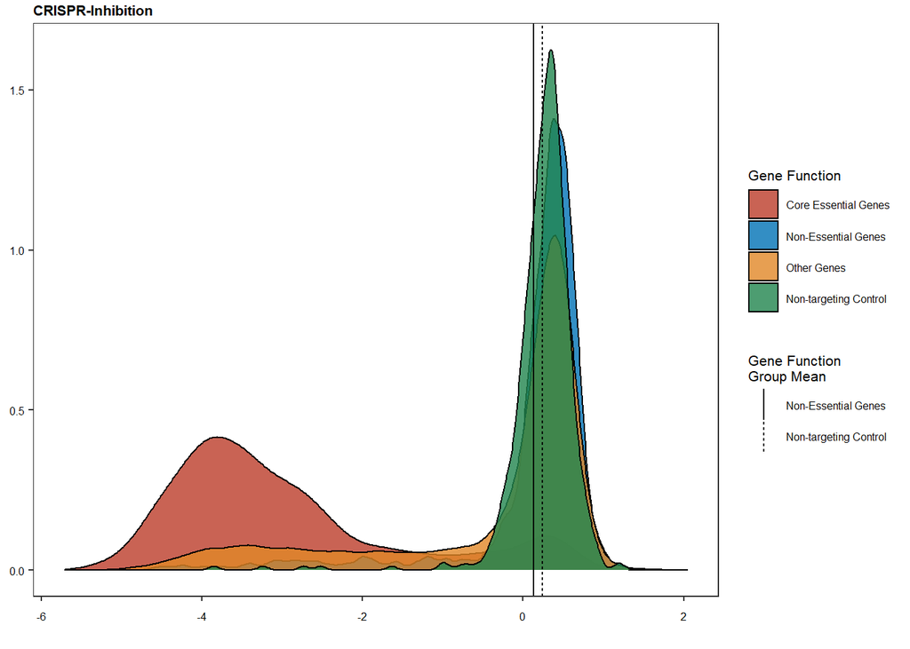

```r
density_inh<-crispri_guide_LFC %>%  ggplot(aes(x=IPSC_D18,fill=factor(func, level=level_order)))+geom_density(color="black", alpha=0.8)+
  scale_fill_nejm(name="Gene Function",                                                          labels=c("CEG"="Core Essential Genes" , "NEG"="Non-Essential Genes", "Other"="Other Genes", "CONTROL"="Non-targeting Control"))+
  theme_su()+
  theme(axis.title = element_blank())+ggtitle("CRISPR-Inhibition ")+
 geom_vline(aes(xintercept=0.243, linetype="Non-targeting Control"))+
  geom_vline(aes(xintercept= 0.129, linetype="Non-Essential Genes"))+scale_linetype(name="Gene Function\nGroup Mean")
density_inh
```

[output not shown]

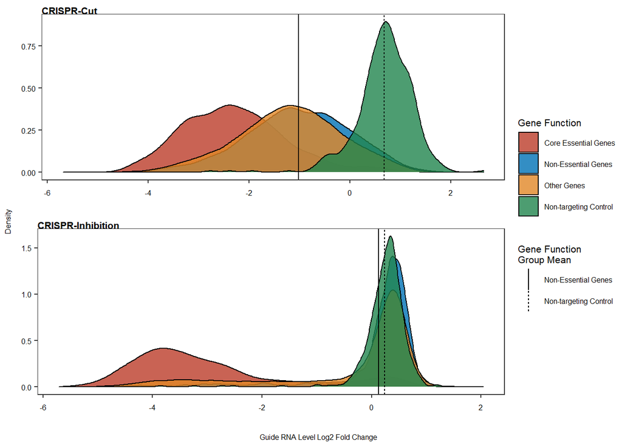

```r
fig_4_g<- ggarrange(density_cut, density_inh, ncol=1, common.legend = T, legend="right")
fig_4_g<- annotate_figure(fig_4_g, bottom=text_grob("Guide RNA Level Log2 Fold Change", size=6), left=text_grob("Density", size=6, rot=90))
fig_4_g
```

```r
ggsave(fig_4_g, filename = "E:/Paper writing/CRIPSRi paper/Analyses/plots/panel_4/fig_4_g.svg", width = 3.5, height = 3.5, units = "in", dpi=1000)
```

##depletion of K562

```r
K562_mean_inh<- crispri_guide_LFC %>% select(func, K562_D21) %>%  group_by(func) %>% summarise(across(
    .cols = where(is.numeric),
    .fns = list(Mean = mean), na.rm = TRUE,
    .names = "{col}_{fn}"
  )) %>% droplevels()
K562_mean_cut<- crispr_guide %>% filter(library==3) %>% select(func, K562_LFC) %>%  group_by(func) %>% summarise(across(
    .cols = where(is.numeric),
    .fns = list(Mean = mean), na.rm = TRUE,
    .names = "{col}_{fn}"
  )) %>% droplevels()


level_order<- c("CEG", "NEG", "Other", "CONTROL")

K562_mean_cut
```

| func | K562_LFC_Mean |
| --- | --- |
| CEG | -1.0709580 |
| CONTROL | 0.0761206 |
| NEG | -0.3403002 |
| Other | -0.4218907 |

[output not shown]

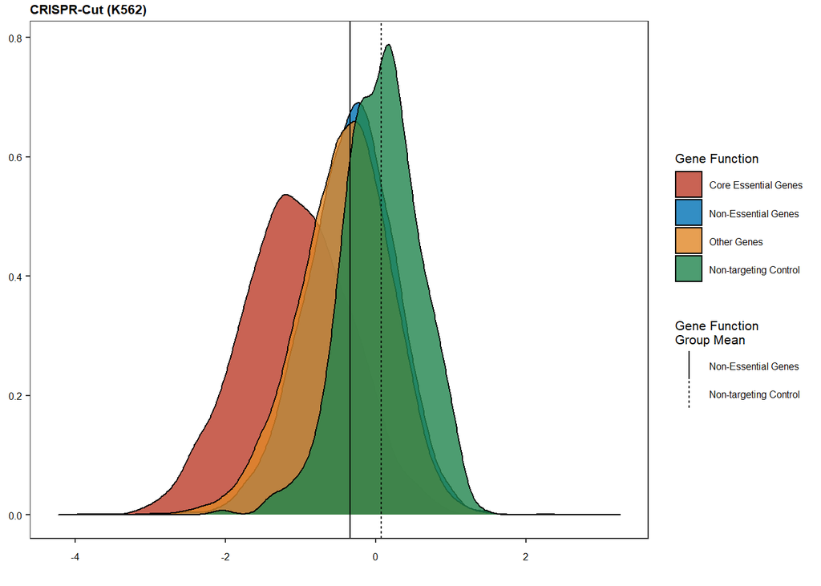

```r
k562_density_cut<-crispr_guide %>% filter(library==3) %>%  ggplot(aes(x=K562_LFC,fill=factor(func, level=level_order)))+geom_density(color="black", alpha=0.8)+
  scale_fill_nejm(name="Gene Function",                                                          labels=c("CEG"="Core Essential Genes" , "NEG"="Non-Essential Genes", "Other"="Other Genes", "CONTROL"="Non-targeting Control"))+
  theme_su()+
  theme(axis.title = element_blank())+ggtitle("CRISPR-Cut (K562) ")+
 geom_vline(aes(xintercept=0.0761, linetype="Non-targeting Control"))+
  geom_vline(aes(xintercept= -0.340, linetype="Non-Essential Genes"))+scale_linetype(name="Gene Function\nGroup Mean")

k562_density_cut
```

```r
K562_mean_inh
```

| func | K562_D21_Mean |
| --- | --- |
| CEG | -2.48807027 |
| CONTROL | 0.04764551 |
| NEG | 0.06994225 |
| Other | -0.18273986 |

[output not shown]

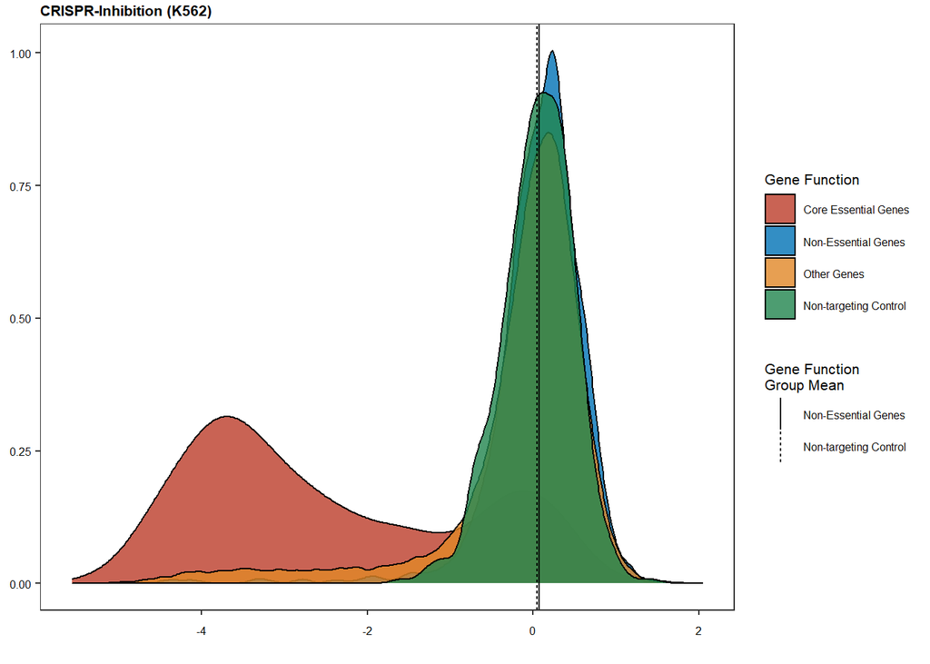

```r
K562_density_inh<-crispri_guide_LFC %>%  ggplot(aes(x=K562_D21,fill=factor(func, level=level_order)))+geom_density(color="black", alpha=0.8)+
  scale_fill_nejm(name="Gene Function",                                                          labels=c("CEG"="Core Essential Genes" , "NEG"="Non-Essential Genes", "Other"="Other Genes", "CONTROL"="Non-targeting Control"))+
  theme_su()+
  theme(axis.title = element_blank())+ggtitle("CRISPR-Inhibition (K562) ")+
 geom_vline(aes(xintercept=0.0476, linetype="Non-targeting Control"))+
  geom_vline(aes(xintercept= 0.0699, linetype="Non-Essential Genes"))+scale_linetype(name="Gene Function\nGroup Mean")
K562_density_inh
```

```r
sup_fig_4_d<- ggarrange(k562_density_cut, K562_density_inh, ncol=1, common.legend = T, legend="right")
sup_fig_4_d<- annotate_figure(sup_fig_4_d, bottom=text_grob("Guide RNA Level Log2 Fold Change", size=6), left=text_grob("Density", size=6, rot=90))
sup_fig_4_d
```

[output not shown]

[figure not shown]

```r
ggsave(sup_fig_4_d, filename = "E:/Paper writing/CRIPSRi paper/Analyses/plots/panel_4/sup_fig_4_d.svg", width = 3.5, height = 3.5, units = "in",dpi=1000)
```